# Reproducible Research - 1st assignment

Rui Almeida

2024-05-05

## Introduction

It is now possible to collect a large amount of data about personal movement using activity monitoring devices such as a Fitbit, Nike Fuelband , or Jawbone Up.

These type of devices are part of the “quantified self” movement – a group of enthusiasts who take measurements about themselves regularly to improve their health, to find patterns in their behavior, or because they are tech geeks. But these data remain under-utilized both because the raw data are hard to obtain and there is a lack of statistical methods and software for processing and interpreting the data.

This assignment makes use of data from a personal activity monitoring device. This device collects data at 5 minute intervals through out the day. The data consists of two months of data from an anonymous individual collected during the months of October and November, 2012 and include the number of steps taken in 5 minute intervals each day.

The variables included in this dataset are steps: Number of steps taking in a 5-minute interval date: The date on which the measurement was taken in YYYY-MM-DD format interval: Identifier for the 5-minute interval in which measurement was taken

```r
#include library to make plots
library(ggplot2)
library(dplyr)
# Loading and preprocessing the data
data <- read.csv("C:/user/rui/Doutoramento/DataScienceSpecialization/Reproducible Research/Trabalho1/activity.csv")
# summary file in order to see if all data as been read
summary(data)
```

```
##      steps            date              interval
##  Min.   :  0.00   Length:17568       Min.   :   0.0
##  1st Qu.:  0.00   Class :character   1st Qu.: 588.8
##  Median :  0.00   Mode  :character   Median :1177.5
##  Mean   : 37.38                      Mean   :1177.5
##  3rd Qu.: 12.00                      3rd Qu.:1766.2
##  Max.   :806.00                      Max.   :2355.0
##  NA's   :2304
```

```r
# Remove rows with NA values in the 'steps' column
data2 <- na.omit(data)

# Convert the 'date' column to Date format
data2$date <- as.Date(data2$date)
data$date <- as.Date(data$date)

# Calculate total steps per day
total_steps_per_day <- aggregate(steps ~ date, data = data, FUN = sum)

# What is mean total number of steps taken per day?
```

## Histogram of the total number of steps taken each day

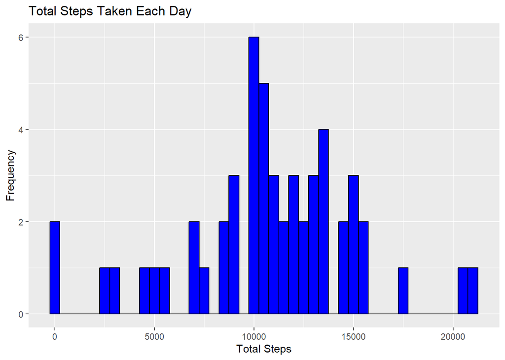

```r
# Create a histogram
ggplot(total_steps_per_day, aes(x = steps)) +
        geom_histogram(binwidth = 500, fill = "blue", color = "black") +
        labs(title = "Total Steps Taken Each Day",
             x = "Total Steps",
             y = "Frequency")
```

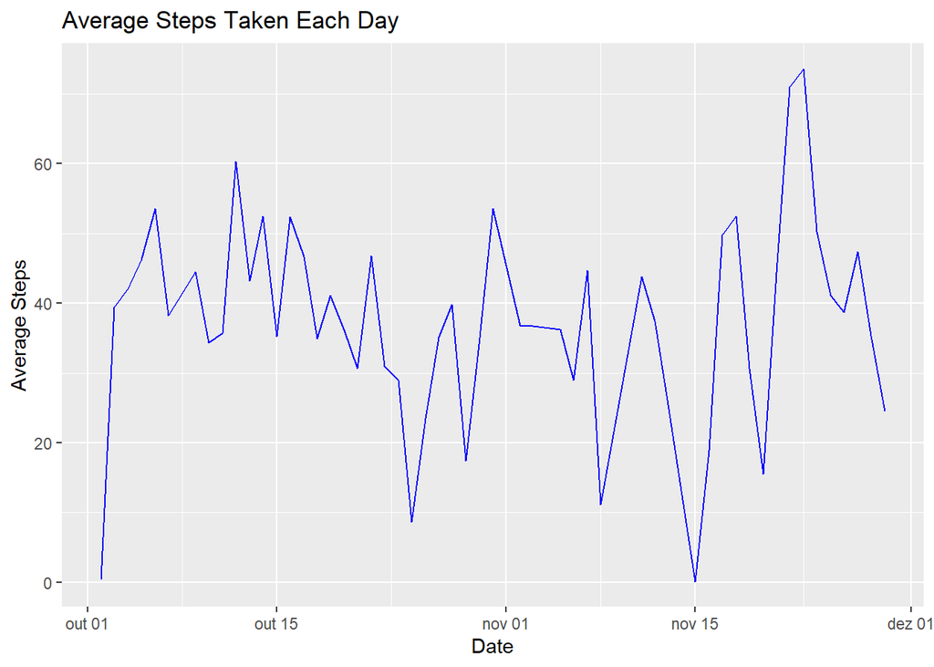

```r
# Calculate mean steps per day
mean_steps_per_day <- aggregate(steps ~ date, data = data2, FUN = mean)

# Remove NA values from average_steps
mean_data <- mean_steps_per_day[!is.na(mean_steps_per_day$steps), ]

# Plot the time series
ggplot(mean_data, aes(x = date, y = steps)) +
        geom_line(color = "blue") +
        labs(title = "Average Steps Taken Each Day",
             x = "Date",
             y = "Average Steps")
```

```r
# Mean and median number of steps taken each day
summary(total_steps_per_day$step)
```

```
##    Min. 1st Qu.  Median    Mean 3rd Qu.    Max.
##      41    8841   10765   10766   13294   21194
```

```r
# Calculate mean and median
mean_daily <- mean(total_steps_per_day$steps)
median_daily <- median(total_steps_per_day$steps)


cat("Mean of Step per day:", mean_daily, "\n")
```

```
## Mean of Step per day: 10766.19
```

```r
cat("Median of Step per day:", median_daily, "\n")
```

```
## Median of Step per day: 10765
```

## Imputing missing values

```r
#Calculate and report the total number of missing values in the dataset

# Count total number of missing values
total_missing <- sum(is.na(data$steps))
cat("Total number of missing values:", total_missing, "\n")
```

```
## Total number of missing values: 2304
```

```r
#Devise a strategy for filling in all of the missing values in the dataset. The strategy does not need to be sophisticated. For example, you could use the mean/median for that day, or the mean for that 5-minute interval, etc.

#Create a new dataset that is equal to the original dataset but with the missing data filled in.


# Calculate mean for each 5-minute interval
mean_interval <- data %>%
        group_by(interval) %>%
        summarise(mean_steps = round(mean(steps, na.rm = TRUE)))

# Merge mean_interval with original dataset to fill missing values
filled_data <- data %>%
        left_join(mean_interval, by = "interval") %>%
        mutate(steps = ifelse(is.na(steps), mean_steps, steps)) %>%
        select(-mean_steps)
# Calculate total steps per day
total_steps_per_day_filled <- aggregate(steps ~ date, data = filled_data, FUN = sum)

# Calculate mean and median
mean_filled <- mean(total_steps_per_day_filled$steps)
median_filled <- median(total_steps_per_day_filled$steps)

cat("Mean total number of Step taken per day:", mean_daily, "\n")
```

```
## Mean total number of Step taken per day: 10766.19
```

```r
cat("Median total number of Step taken per day:", median_daily, "\n")
```

```
## Median total number of Step taken per day: 10765
```

```r
cat("Mean total number of steps taken per day (filled data):", mean_filled, "\n")
```

```
## Mean total number of steps taken per day (filled data): 10765.64
```

```r
cat("Median total number of steps taken per day (filled data):", median_filled, "\n")
```

```
## Median total number of steps taken per day (filled data): 10762
```

```r
# Check which situation has greater mean and median values
if (mean_daily > mean_filled) {
  cat("Mean total number of steps taken per day is greater before filling missing values.\n")
} else if (mean_daily < mean_filled) {
  cat("Mean total number of steps taken per day is greater after filling missing values.\n")
} else {
  cat("Mean total number of steps taken per day is the same before and after filling missing values.\n")
}
```

```
## Mean total number of steps taken per day is greater before filling missing values.
```

```r
if (median_daily > median_filled) {
  cat("Median total number of steps taken per day is greater before filling missing values.\n")
} else if (median_daily < median_filled) {
  cat("Median total number of steps taken per day is greater after filling missing values.\n")
} else {
  cat("Median total number of steps taken per day is the same before and after filling missing values.\n")
}
```

```
## Median total number of steps taken per day is greater before filling missing values.
```

## Histogram of the total number of steps taken each day from data that is filled on NA values

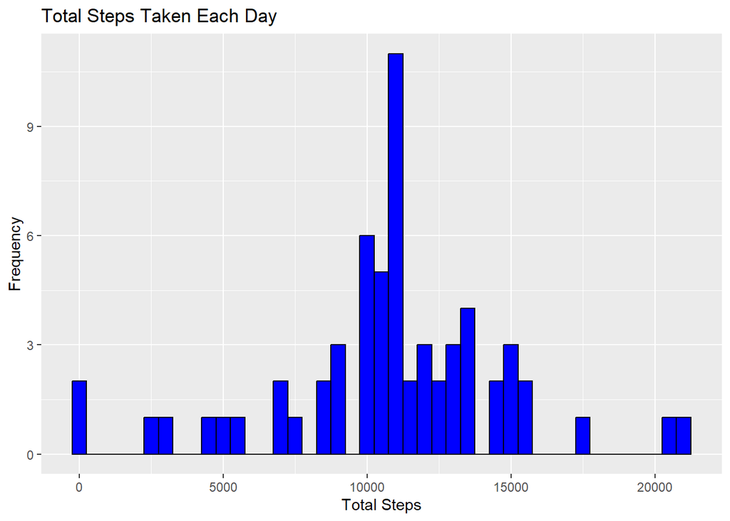

```r
#Make a histogram of the total number of steps taken each day

# Create a histogram
ggplot(total_steps_per_day_filled, aes(x = steps)) +
        geom_histogram(binwidth = 500, fill = "blue", color = "black") +
        labs(title = "Total Steps Taken Each Day",
             x = "Total Steps",
             y = "Frequency")
```

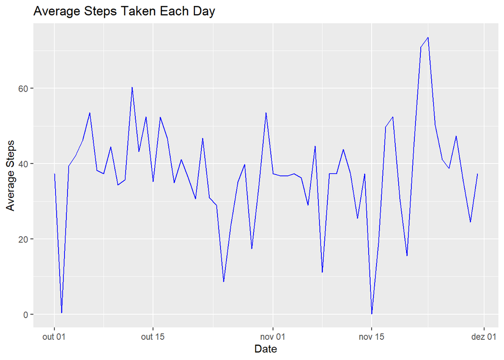

```r
# Calculate mean steps per day
mean_steps_per_day_filled <- aggregate(steps ~ date, data = filled_data, FUN = mean)

# Remove NA values from average_steps
mean_data_noNA <- mean_steps_per_day_filled[!is.na(mean_steps_per_day_filled$steps), ]

# Plot the time series
ggplot(mean_data_noNA, aes(x = date, y = steps)) +
        geom_line(color = "blue") +
        labs(title = "Average Steps Taken Each Day",
             x = "Date",
             y = "Average Steps")
```

```r
# Find the interval with the maximum average number of steps
max_date <- mean_steps_per_day_filled[which.max(mean_steps_per_day_filled$steps), "date"]
max_average_steps <- max(mean_steps_per_day_filled$steps)

cat("Date ", format(max_date, format = "%Y-%m-%d") , "has the maximum average number of steps:", max_average_steps, "\n")
```

```
## Date  2012-11-23 has the maximum average number of steps: 73.59028
```

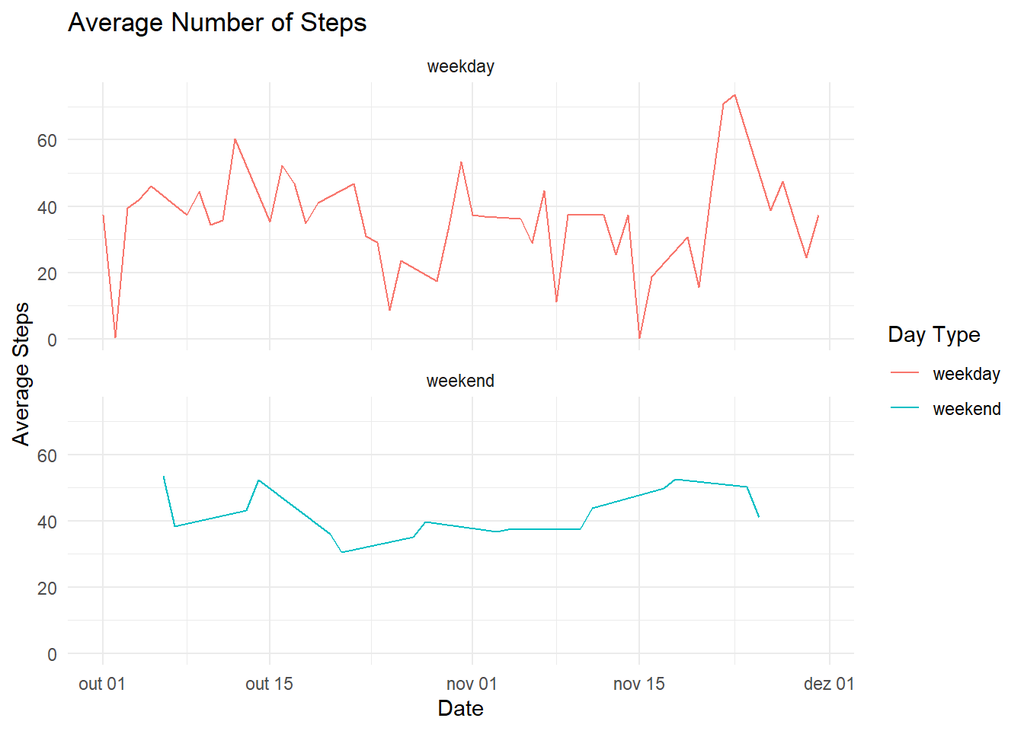

```r
# Are there differences in activity patterns between weekdays and weekends?
# Create a new factor variable indicating weekdays and weekends

mean_steps_per_day_filled$Weekday <- weekdays(mean_steps_per_day_filled$date, abbreviate = TRUE)
mean_steps_per_day_filled$day_type <- ifelse(weekdays(mean_steps_per_day_filled$date, abbreviate = TRUE) %in% c("sáb", "dom"), "weekend", "weekday") # if the regional setting are in English you must change for c("sat", "sun")
mean_steps_per_day_filled$day_type <- factor(mean_steps_per_day_filled$day_type, levels = c("weekday", "weekend"))



# Create panel plot
ggplot(mean_steps_per_day_filled, aes(x = date, y = steps, group = day_type, color = day_type)) +
        geom_line() +
        facet_wrap(~ day_type, ncol = 1) +
        labs(title = "Average Number of Steps ",
             x = "Date",
             y = "Average Steps",
             color = "Day Type") +
        theme_minimal()
```